# Regression Tree Analysis of Red Wine Data

STAT6620, Spring 2016, HW # 5

Abe-Jones, Yumiko

May 1, 2016

The objective of this analytical exercise is to build a model that mimics experts’ ratings of wine, and to identify the key factors that help wines earn higher ratings. We compare two algorithms, CART and M5’.

### I: Get the data

```r
wine <- read.csv("redwines.csv")
```

### II: Explore and prepare the data for modeling

#### Explore the data

```r
str(wine)
```

```
## 'data.frame':    1599 obs. of  12 variables:
##  $ fixed.acidity       : num  6.5 9.1 6.9 7.3 12.5 5.4 10.4 7.9 7.3 9.5 ...
##  $ volatile.acidity    : num  0.9 0.22 0.52 0.59 0.28 0.74 0.28 0.4 0.39 0.37 ...
##  $ citric.acid         : num  0 0.24 0.25 0.26 0.54 0.09 0.54 0.3 0.31 0.52 ...
##  $ residual.sugar      : num  1.6 2.1 2.6 2 2.3 1.7 2.7 1.8 2.4 2 ...
##  $ chlorides           : num  0.052 0.078 0.081 0.08 0.082 0.089 0.105 0.157 0.074 0.088 ...
##  $ free.sulfur.dioxide : num  9 1 10 17 12 16 5 2 9 12 ...
##  $ total.sulfur.dioxide: num  17 28 37 104 29 26 19 45 46 51 ...
##  $ density             : num  0.995 0.999 0.997 0.996 1 ...
##  $ pH                  : num  3.5 3.41 3.46 3.28 3.11 3.67 3.25 3.31 3.41 3.29 ...
##  $ sulphates           : num  0.63 0.87 0.5 0.52 1.36 0.56 0.63 0.91 0.54 0.58 ...
##  $ alcohol             : num  10.9 10.3 11 9.9 9.8 11.6 9.5 9.5 9.4 11.1 ...
##  $ quality             : int  6 6 5 5 7 6 5 6 6 6 ...
```

We see that the dataset has 1599 rows and 12 numerical variables, of which 11 are explanatory. The target variable is *quality*, which is an integer. How are these quality scores distributed? Let’s do a histogram:

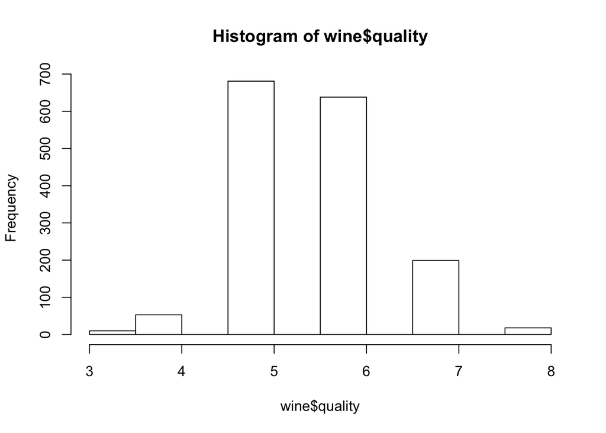

```r
hist(wine$quality)
```

```r
summary(wine$quality)
```

```
##    Min. 1st Qu.  Median    Mean 3rd Qu.    Max.
##   3.000   5.000   6.000   5.636   6.000   8.000
```

…so we see that these scores are distributed normally between 3 and 8, with the greatest between 5 and 6, closer to 5, but with more scores above the hump than below.

The summary gives us a mean quality score of 5.636.

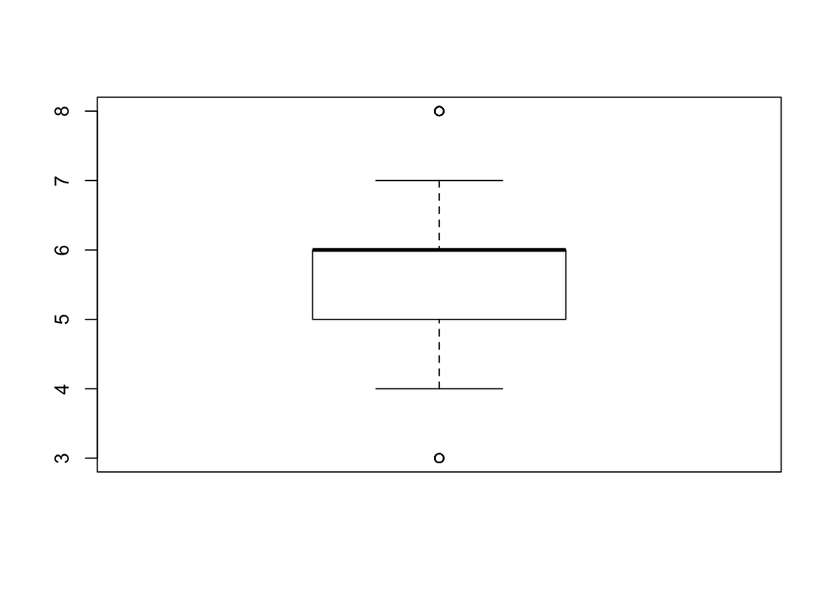

```r
boxplot(wine$quality)
```

#### Prepare the data for modeling

We’ll now divide up the wine data into a training and a test dataset for subsequent modeling in the third step. We’ll use dplyr’s handy sample_frac method.

```r
library(dplyr)
set.seed(99)
wine_train <- sample_frac(wine, .85)
wine_test <- setdiff(wine,wine_train)
str(wine_train)
```

```
## 'data.frame':    1359 obs. of  12 variables:
##  $ fixed.acidity       : num  9 7.1 9.7 7.3 12 7.5 8.4 10.7 10.3 6.9 ...
##  $ volatile.acidity    : num  0.43 0.48 0.295 0.38 0.39 0.55 0.39 0.4 0.5 0.36 ...
##  $ citric.acid         : num  0.34 0.28 0.4 0.21 0.66 0.24 0.1 0.48 0.42 0.25 ...
##  $ residual.sugar      : num  2.5 2.8 1.5 2 3 2 1.7 2.1 2 2.4 ...
##  $ chlorides           : num  0.08 0.068 0.073 0.08 0.093 0.078 0.075 0.125 0.069 0.098 ...
##  $ free.sulfur.dioxide : num  26 6 14 7 12 10 6 15 21 5 ...
##  $ total.sulfur.dioxide: num  86 16 21 35 30 28 25 49 51 16 ...
##  $ density             : num  0.999 0.997 0.996 0.996 1 ...
##  $ pH                  : num  3.38 3.24 3.14 3.33 3.18 3.45 3.09 3.03 3.16 3.41 ...
##  $ sulphates           : num  0.62 0.53 0.51 0.47 0.63 0.78 0.43 0.81 0.72 0.6 ...
##  $ alcohol             : num  9.5 10.3 10.9 9.5 10.8 9.5 9.7 9.7 11.5 10.1 ...
##  $ quality             : int  6 5 6 5 7 6 6 6 6 6 ...
```

```r
str(wine_test)
```

```
## 'data.frame':    175 obs. of  12 variables:
##  $ fixed.acidity       : num  6.5 9.1 7.2 6.2 8.9 8.8 7.2 7.7 12.3 10.5 ...
##  $ volatile.acidity    : num  0.9 0.3 0.62 0.52 0.59 0.42 0.45 0.27 0.27 0.28 ...
##  $ citric.acid         : num  0 0.34 0.01 0.08 0.5 0.21 0.15 0.68 0.49 0.51 ...
##  $ residual.sugar      : num  1.6 2 2.3 4.4 2 2.5 2 3.5 3.1 1.7 ...
##  $ chlorides           : num  0.052 0.064 0.065 0.071 0.337 0.092 0.078 0.358 0.079 0.08 ...
##  $ free.sulfur.dioxide : num  9 12 8 11 27 33 10 5 28 10 ...
##  $ total.sulfur.dioxide: num  17 25 46 32 81 88 28 10 46 24 ...
##  $ density             : num  0.995 0.995 0.993 0.996 0.996 ...
##  $ pH                  : num  3.5 3.26 3.32 3.56 3.04 3.19 3.29 3.25 3.2 3.2 ...
##  $ sulphates           : num  0.63 0.84 0.51 0.63 1.61 0.52 0.51 1.08 0.8 0.89 ...
##  $ alcohol             : num  10.9 11.7 11.8 11.6 9.5 9.2 9.9 9.9 10.2 9.4 ...
##  $ quality             : int  6 7 6 6 6 5 6 7 6 6 ...
```

This gives us a training dataset consisting of 1,359 observations, and a testing dataset consisting of 175 observations.

### III: Train the model

Using the CART algorithm implemented in the **rpart** package, we run and take a look at the tree:

```r
library(rpart)
m.rpart <- rpart(quality ~ ., data=wine_train)
m.rpart
```

```
## n= 1359
##
## node), split, n, deviance, yval
##       * denotes terminal node
##
##  1) root 1359 881.24210 5.634290
##    2) alcohol< 10.525 828 355.68480 5.373188
##      4) volatile.acidity>=0.335 755 292.43180 5.320530
##        8) sulphates< 0.535 183  46.33880 5.060109 *
##        9) sulphates>=0.535 572 229.71150 5.403846
##         18) total.sulfur.dioxide>=46.5 275  97.14909 5.261818 *
##         19) total.sulfur.dioxide< 46.5 297 121.87880 5.535354 *
##      5) volatile.acidity< 0.335 73  39.50685 5.917808 *
##    3) alcohol>=10.525 531 381.08850 6.041431
##      6) sulphates< 0.645 237 172.51480 5.691983
##       12) volatile.acidity>=1.015 9   6.00000 4.000000 *
##       13) volatile.acidity< 1.015 228 139.73250 5.758772
##         26) volatile.acidity>=0.315 195 110.28720 5.651282 *
##         27) volatile.acidity< 0.315 33  13.87879 6.393939 *
##      7) sulphates>=0.645 294 156.30270 6.323129
##       14) alcohol< 11.55 179  87.76536 6.111732 *
##       15) alcohol>=11.55 115  48.08696 6.652174 *
```

We see that our model tree sports nine terminal nodes. In agreement with the white wine data, alcohol appears to be the most important predictor of wine quality as it is the first split made. We may then look at additional features about the tree:

```r
summary(m.rpart)
```

```
## Call:
## rpart(formula = quality ~ ., data = wine_train)
##   n= 1359
##
##           CP nsplit rel error    xerror       xstd
## 1 0.16393769      0 1.0000000 1.0017488 0.04160576
## 2 0.05931517      1 0.8360623 0.8532567 0.03995902
## 3 0.03039155      2 0.7767471 0.8160731 0.03640288
## 4 0.02694622      3 0.7463556 0.8023760 0.03548789
## 5 0.02320634      4 0.7194094 0.7775031 0.03426898
## 6 0.01858905      5 0.6962030 0.7612793 0.03324178
## 7 0.01766426      6 0.6776140 0.7464285 0.03268464
## 8 0.01212341      7 0.6599497 0.7295344 0.03220348
## 9 0.01000000      8 0.6478263 0.7252889 0.03200620
##
## Variable importance
##              alcohol     volatile.acidity              density
##                   31                   18                   14
##            sulphates            chlorides        fixed.acidity
##                   13                    6                    6
## total.sulfur.dioxide          citric.acid                   pH
##                    4                    4                    2
##  free.sulfur.dioxide       residual.sugar
##                    2                    1
##
## Node number 1: 1359 observations,    complexity param=0.1639377
##   mean=5.63429, MSE=0.6484489
##   left son=2 (828 obs) right son=3 (531 obs)
##   Primary splits:
##       alcohol          < 10.525   to the left,  improve=0.16393770, (0 missing)
##       sulphates        < 0.645    to the left,  improve=0.12044530, (0 missing)
##       volatile.acidity < 0.425    to the right, improve=0.10704310, (0 missing)
##       citric.acid      < 0.305    to the left,  improve=0.06510594, (0 missing)
##       density          < 0.995575 to the right, improve=0.05895058, (0 missing)
##   Surrogate splits:
##       density              < 0.995575 to the right, agree=0.760, adj=0.386, (0 split)
##       chlorides            < 0.0685   to the right, agree=0.682, adj=0.186, (0 split)
##       volatile.acidity     < 0.375    to the right, agree=0.657, adj=0.122, (0 split)
##       fixed.acidity        < 6.75     to the right, agree=0.646, adj=0.094, (0 split)
##       total.sulfur.dioxide < 17.5     to the right, agree=0.639, adj=0.077, (0 split)
```

[output cut: 115 more lines]

```
##
## Node number 15: 115 observations
##   mean=6.652174, MSE=0.4181474
##
## Node number 18: 275 observations
##   mean=5.261818, MSE=0.3532694
##
## Node number 19: 297 observations
##   mean=5.535354, MSE=0.4103663
##
## Node number 26: 195 observations
##   mean=5.651282, MSE=0.5655753
##
## Node number 27: 33 observations
##   mean=6.393939, MSE=0.4205693
```

Since the text-based visualization of the tree is difficult to grasp, we use the **rpart.plot** package to get a better look:

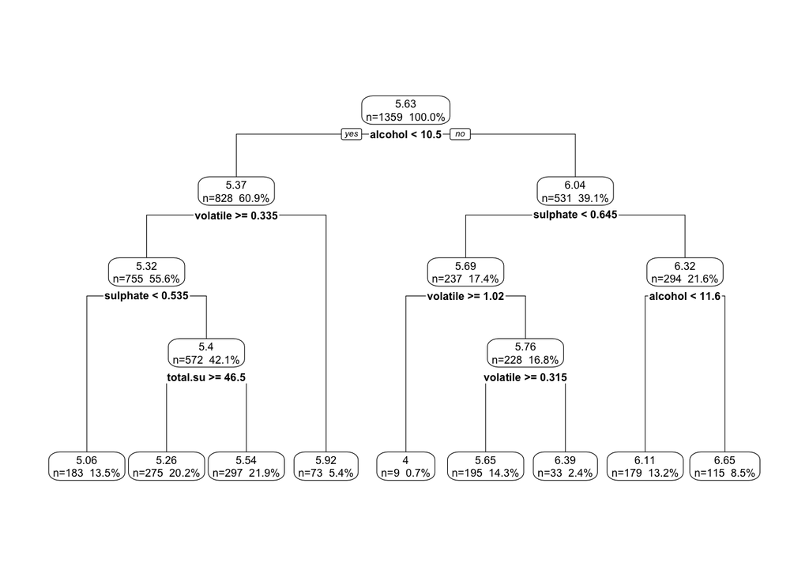

```r
library(rpart.plot)
rpart.plot(m.rpart, digits=3, fallen.leaves = TRUE,
           type = 2, extra = 101)
```

The model came up with nine predicted quality groupings as follows (right to left on tree diagram):

| Score | Predictor variable values |
| --- | --- |
| 6.65 | alcohol >= 11.6, sulphate >= 0.645 |
| 6.11 | 11.6 > alcohol >= 10.5, sulphate >= 0.645 |
| 6.39 | alcohol >= 10.5, sulphate < 0.645, volatile < 0.315 |
| 5.65 | alcohol >= 10.5, sulphate < 0.645, 1.02 >= volatile >= 0.315 |
| 4.00 | alcohol >= 10.5, sulphate < 0.645, volatile >= 1.02 |
| 5.92 | alcohol < 10.5, volatile < 0.335 |
| 5.54 | alcohol < 10.5, volatile >= 0.335, sulphate >= 0.535, total.su < 46.5 |
| 5.26 | alcohol < 10.5, volatile >= 0.335, sulphate >= 0.535, total.su >= 46.5 |
| 5.06 | alcohol < 10.5, volatile >= 0.335, sulphate < 0.535 |

### IV: Evaluate model performance

Using the predict() function, evaluate model’s performance. Create prediction vector p.rpart, and compare its values to actual *quality* values from wine_test:

```r
p.rpart <- predict(m.rpart, wine_test)
summary(p.rpart)
```

```
##    Min. 1st Qu.  Median    Mean 3rd Qu.    Max.
##   4.000   5.262   5.535   5.614   5.918   6.652
```

```r
summary(wine_test$quality)
```

```
##    Min. 1st Qu.  Median    Mean 3rd Qu.    Max.
##   3.000   5.000   5.000   5.629   6.000   8.000
```

It appears that the actual values are much more spread out than the predicted values. Look at the *correlation* between the predicted and actual quality scores to see how they relate to one another:

```r
cor(p.rpart, wine_test$quality)
```

```
## [1] 0.6270712
```

…and at 0.627, it appears that the scores are not particularly related to one another, although it could be worse.

#### Evaluate the model using Mean Absolute Value (MAE)

MAE is the average error, or absolute difference between actual and predicted values.

[output not shown]

The average difference between the predicted and actual values is about 0.515.

Is this good or bad? We compare the performance of our model with a “model” that predicts every wine’s quality score to be the mean score in the training dataset:

```r
mean(wine_train$quality)
```

```
## [1] 5.63429
```

The mean score of our training dataset is 5.63429. Now calculate the MAE between the actual scores vs. a score of 5.63429 for every single sample:

```r
MAE(5.63429,wine_test$quality)
```

```
## [1] 0.7350531
```

We see that the MAE of our model is about 0.22 less than simply using a guess of the mean score for every sample.

### V. Improve the model.

Try the M5’ algorighm (RWeka package) to see if we get a better result. Create and examine the new model using the same training dataset.

```r
library(RWeka)
m.m5p <- M5P(quality ~ ., data=wine_train)
m.m5p
```

```
## M5 pruned model tree:
## (using smoothed linear models)
##
## alcohol <= 10.525 :
## |   total.sulfur.dioxide <= 70.5 :
## |   |   sulphates <= 0.555 : LM1 (183/65.213%)
## |   |   sulphates >  0.555 :
## |   |   |   volatile.acidity <= 0.605 :
## |   |   |   |   sulphates <= 0.695 :
## |   |   |   |   |   sulphates <= 0.585 :
## |   |   |   |   |   |   volatile.acidity <= 0.57 : LM2 (34/63.031%)
## |   |   |   |   |   |   volatile.acidity >  0.57 :
## |   |   |   |   |   |   |   citric.acid <= 0.05 : LM3 (3/0%)
## |   |   |   |   |   |   |   citric.acid >  0.05 : LM4 (8/87.811%)
## |   |   |   |   |   sulphates >  0.585 : LM5 (144/68.939%)
## |   |   |   |   sulphates >  0.695 :
## |   |   |   |   |   chlorides <= 0.097 : LM6 (82/71.374%)
## |   |   |   |   |   chlorides >  0.097 : LM7 (34/71.547%)
## |   |   |   volatile.acidity >  0.605 : LM8 (132/76.697%)
## |   total.sulfur.dioxide >  70.5 : LM9 (208/50.686%)
## alcohol >  10.525 :
## |   sulphates <= 0.645 : LM10 (237/88.479%)
## |   sulphates >  0.645 : LM11 (294/81.06%)
##
## LM num: 1
## quality =
##  0.0046 * fixed.acidity
##  - 0.8422 * volatile.acidity
##  - 0.0689 * citric.acid
##  + 0.0006 * residual.sugar
##  - 6.1158 * chlorides
##  + 0.0001 * free.sulfur.dioxide
##  - 0.0001 * total.sulfur.dioxide
##  - 0.0348 * pH
##  + 2.3439 * sulphates
##  + 0.3662 * alcohol
##  + 1.5299
##
## LM num: 2
## quality =
```

[output cut: 122 more lines]

```
##  + 6.5398
##
## LM num: 11
## quality =
##  -0.0686 * volatile.acidity
##  - 3.2239 * chlorides
##  + 0.0006 * free.sulfur.dioxide
##  - 0.0071 * total.sulfur.dioxide
##  - 1.7947 * density
##  - 0.0537 * pH
##  + 1.0074 * sulphates
##  + 0.3039 * alcohol
##  + 4.5506
##
## Number of Rules : 11
```

```r
summary(m.m5p)
```

```
##
## === Summary ===
##
## Correlation coefficient                  0.6749
## Mean absolute error                      0.4689
## Root mean squared error                  0.5945
## Relative absolute error                 68.9162 %
## Root relative squared error             73.831  %
## Total Number of Instances             1359
```

We notice that the first split occurs on alcohol in this model as well, so it remains the key factor in determining the wine quality rating.

Proceed to apply the model to test data; calculate correlation and MAE for comparison with rpart model:

```r
p.m5p <- predict(m.m5p, wine_test)
summary(p.m5p)
```

```
##    Min. 1st Qu.  Median    Mean 3rd Qu.    Max.
##   4.795   5.235   5.531   5.662   6.083   7.187
```

```r
cor(p.m5p, wine_test$quality)
```

```
## [1] 0.6562415
```

```r
MAE(wine_test$quality, p.m5p)
```

```
## [1] 0.4996567
```

MAE obtained with the M5’ algorithm (0.500) is about 0.015 lower than the MAE obtained with the original rpart algorithm (0.515). The correlation values is a few points higher than the CART result as well, but isn’t as dramatically better as the MAE is.

### Conclusion

As we can see from the summary below, the M5’ algorithm barely barely squeaked out a win over CART with a lower Mean Absolute Error and a higher correlation between predicted and actual scores, and appears to be a slightly more favorable choice for predicting expert ratings for this set of wine data. I didn’t really see any good alternative measures between the two models that might allow for comparison.

Both models agree on alcohol as the key factor in determining wine quality.

```
##   Algorithm   MAE Correlation
## 1      CART 0.515       0.627
## 2       M5' 0.500       0.656
```